# Exploração de dados da Wikimedia Foundation

## 2. Quais resultados as pessoas tendem a tentar primeiro? Como isto varia diariamente?

A contagem de frequência dos valores da medida *first_click* mostra que os usuários tentam o primeiro resultado mostrado.

```
##    Min. 1st Qu.  Median    Mean 3rd Qu.    Max.    NA's
##    1.00    1.00    1.00    3.93    2.00 4103.00  102899
```

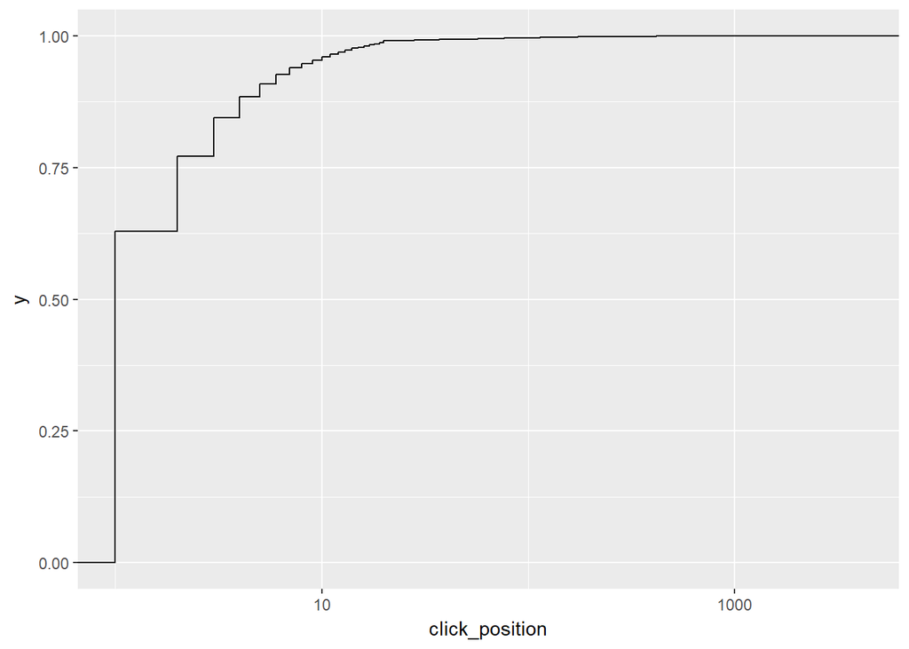

O primeiro clique está relacionado a quantidade de resultados retornados. Em determinados dias os usuários tentaram com o primeiro clique buscas com altas quantidades de resultados, sendo estas buscas em sua maioria realizadas pelo grupo a.

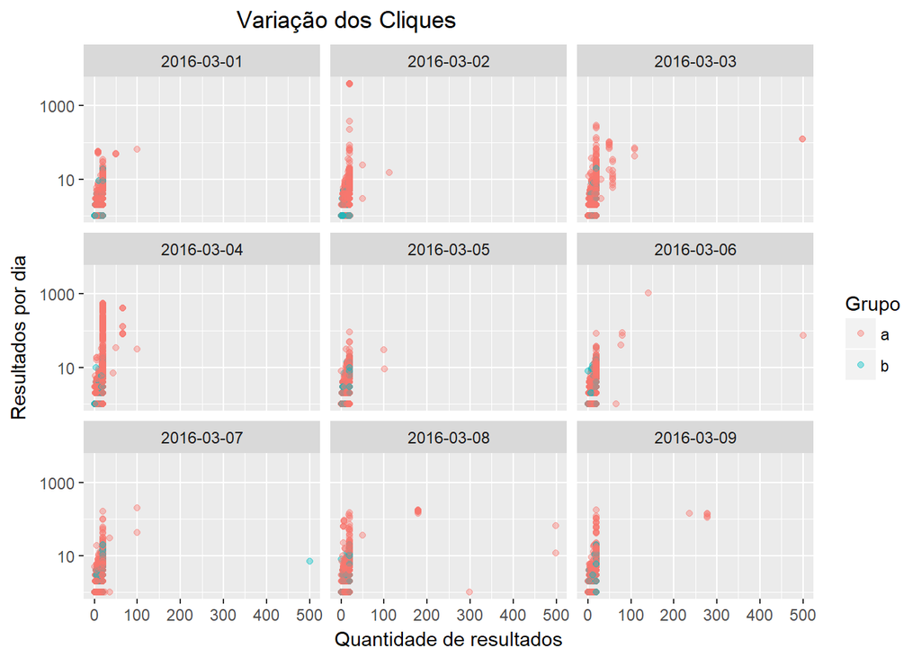